# Seaside Sparrow geographic and subspecies song structure variation analysis

…………………………………………………………………………………………..

The first step I took was to measure and count aspects of the song such as the introductory and terminal buzz length as well as the number of syllables in the song. I wanted to examine if a measurable difference existed between subspecies along the Gulf and Atlantic coastlines. To do this I created box plots to examine the physical characteristics of songs between the subspecies. For these plots **S_D** is the total length (sec) for the song, **TB_MeF** is the mean frequency for the terminal buzz, **TB_D** is the duration of the terminal buzz (sec), and **SC** is the number of syllables in the song.

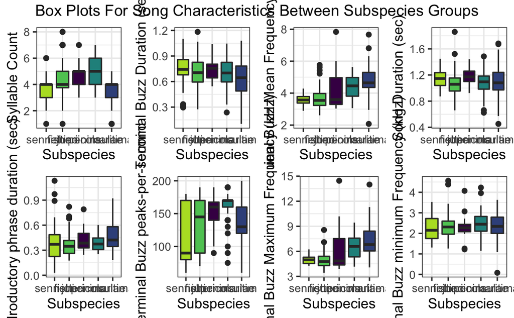

Next, I looked at all of my Song measurements using a PCA to determine what variables had the strongest explanatory power in my data set.

In addition to the variables used in the box plot I also included **S_D** as the total song duration (sec), **TB_MaF & TB_MiF** are the maximum and minimum frequencies for the terminal buzz (kHz), and **TB_Pps** is the number of high frequency peaks per second in the terminal buzz. For the first run the PCA shows that the terminal buzz mean, and max frequency, as well as the song duration and terminal buzz duration are having the greatest impact on the Principle components.

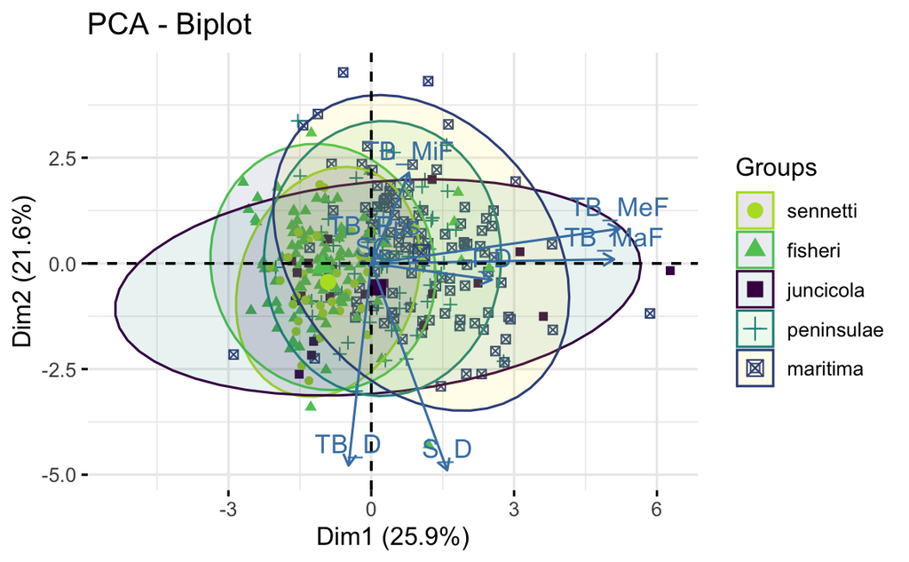

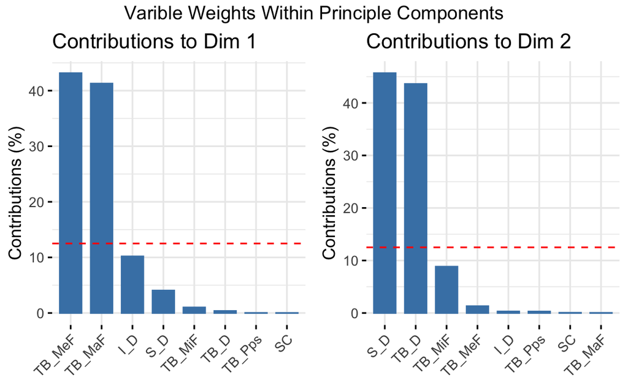

I refined the PCA to and re-printed the box charts with the the most heavily weighted variables. I aslo included the syllable count variable that the earlier boxplot showed separation between the subspecies.

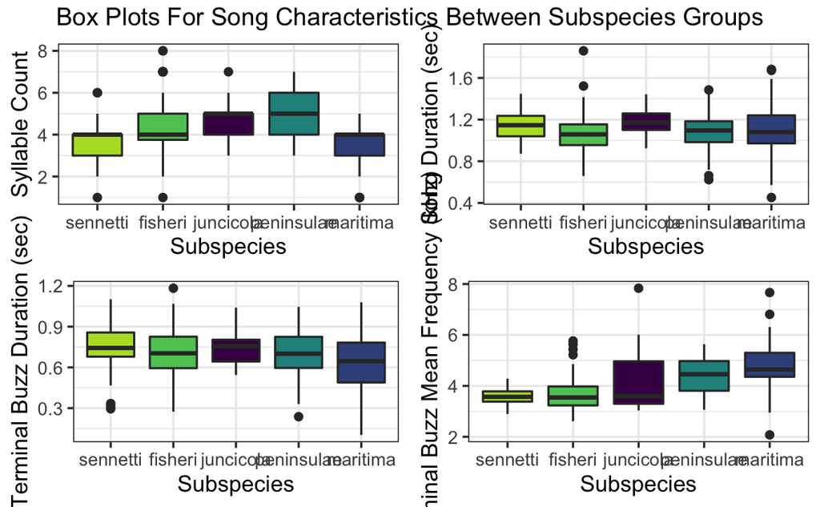

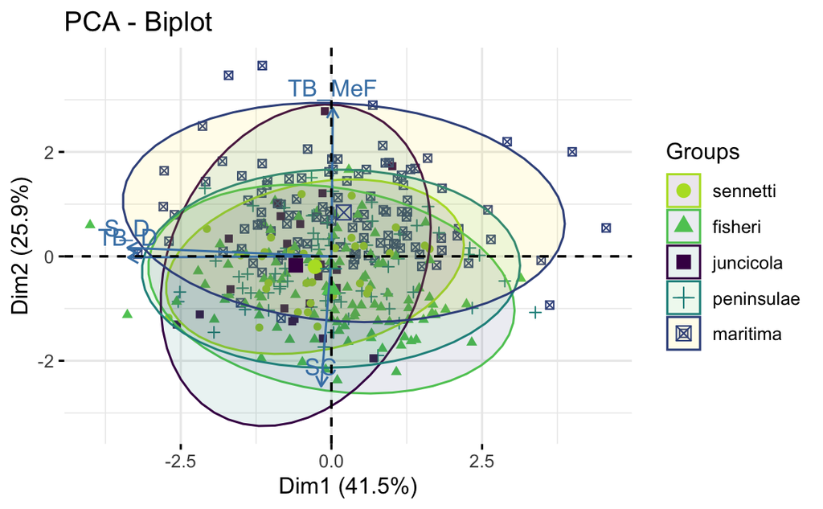

Basic_2 <- Basic %>% select(4:7)

ssp.pca2 <- prcomp(Basic_2, center = TRUE, scale = TRUE)

print(pca.plot2)

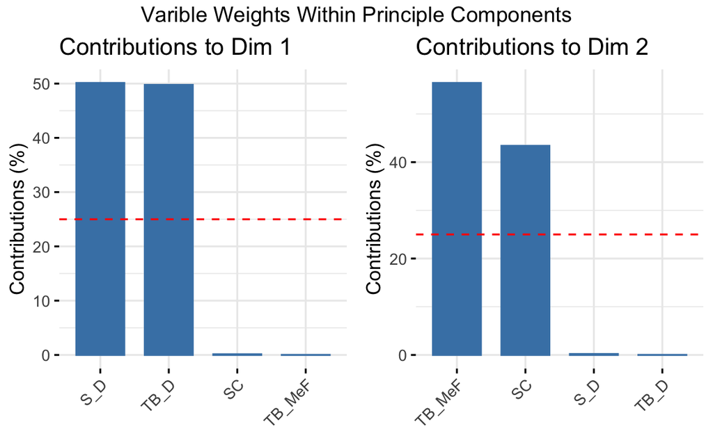

The PCA ellipse display shows that a significant amount of overlap exists across the subspecies regardless of the variables being examined, showing no clear separation or pattern in measurable song characteristics between subspecies.

The next last step was to examine the syllable identity of each syllable of every song in the dataset to determine if any pattern existed in syllable inclusion based on geographic separation or subspecies designation.

To do this each syllable was examined and separated into six bins: Buzz Syllables, Complex Syllables, Trills, Whistle Syllables, Whistle-buzz Syllables, and Whistle-trill Syllables. Once binned by type each syllable was further grouped into syllable IDs based on morphology and frequency. Approximately 200 syllables were identified.

I used a power analysis to determine a minimum threshold of nine occurrences of a specific syllable within the dataset to be included in the analysis to weed out possible outliers and improvisations. I then plotted the resulting syllables based on their location and subspecies song that the syllable was recorded in to examine if a pattern existed.

[interactive chart not shown]

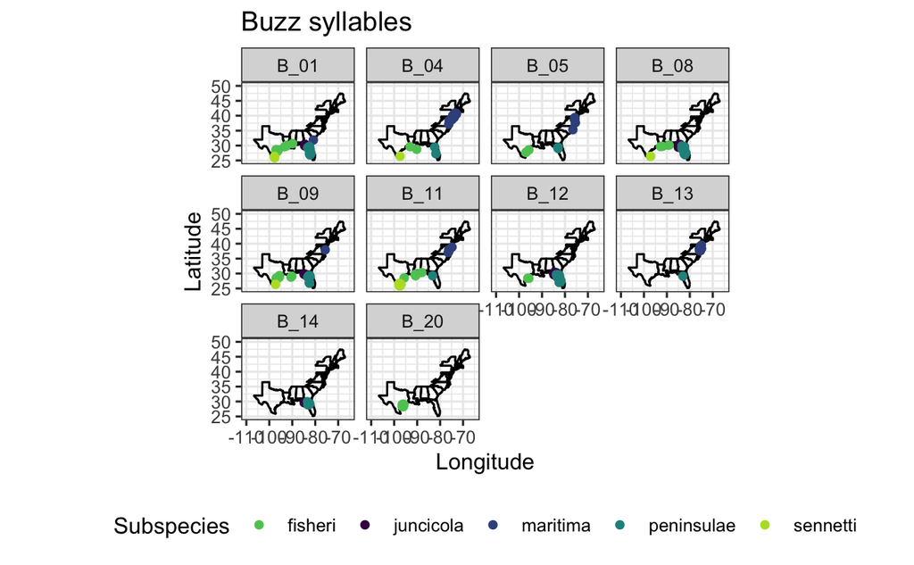

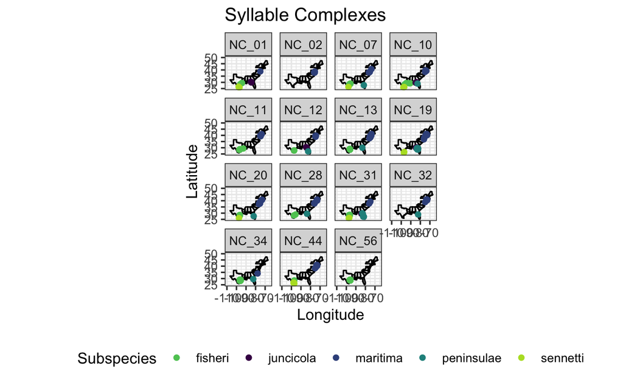

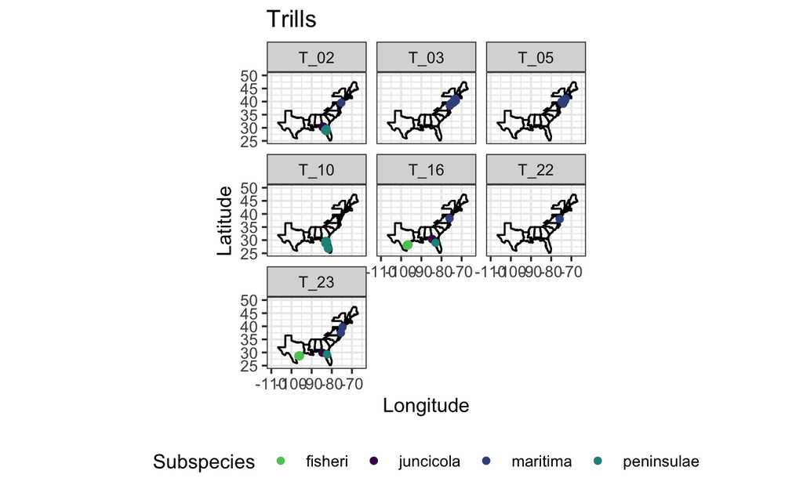

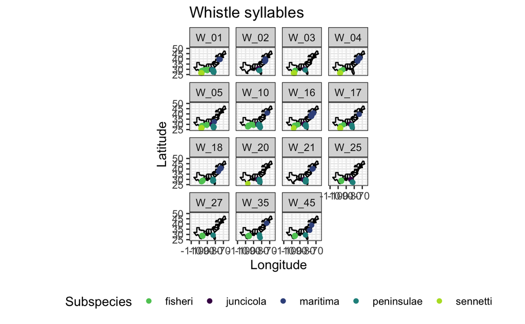

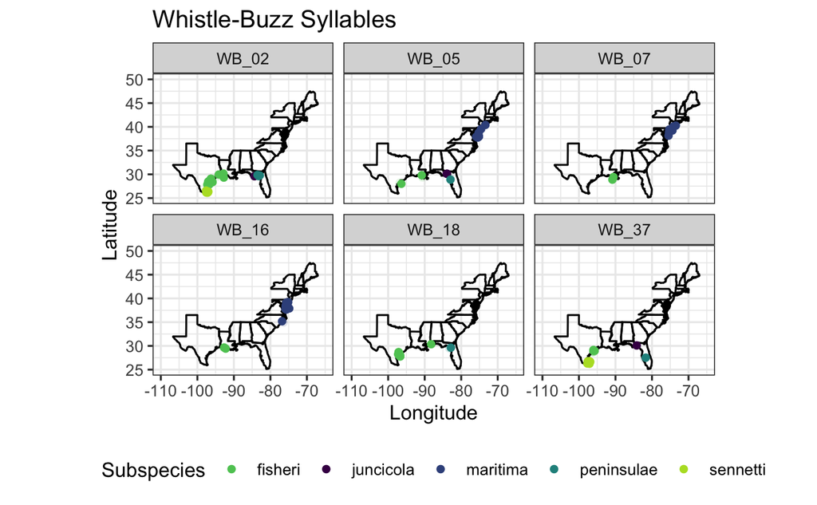

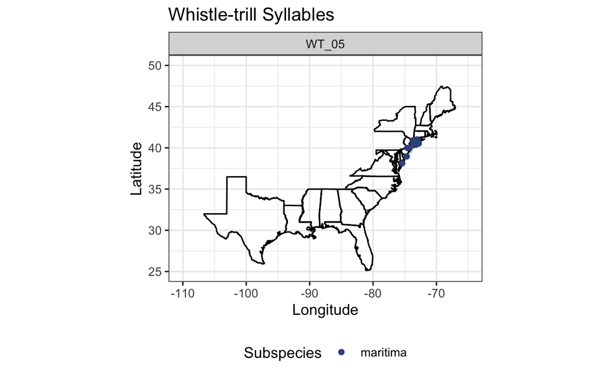

What I have interpreted from these plots is that, broadly speaking, there is no pattern or frequent partitioning of syllables by location or subspecies. My original goal was to test the current hypothesis touched on by John William Hardy in 1983, **that it is reasonable to assume that sedentary birds such as seaside sparrows, that possess multiple song types within their repertoire, are likely to exhibit geographic variation in song including the formation of dialects.** It would follow that if this theory were true, some partitioning of song through measurable characteristics or localized grouping of select syllables unique to specific populations should be visible. Thus, I am forced to conclude that if such variation or partitioning exists, it is at a finer scale that this analysis can account for.

An alternative explanation is that the syllables that occur most frequently, do so **because** they are “common” syllables found across the species range. Unfortunately, I am not sure how I could test this without a much larger data set with multiple re-samplings at fixed sites.

From here I decided to pivot reexamine my data based on a simpler question.

**Does Geographic variation exists between the two coast groups of Seaside Sparrow subspecies?**

[figure not shown]

After looking at the distribution of syllables earlier I concluded that no obvious geographic pattern or partitioning could be easily described. I was however curious as to the ratios that existed within shared syllables in the data set. To explore this, and to account for a larger proportion of Gulf coast points in my data set, I randomly sample unique syllables 10,000 times from within each coastal group with replacement. I used this new data table to examine if there is a trend in the proportions in which syllables occur between the two coastal groups.

Finally, I thought to look at the rate of syllable accumulation between the two coastal groups. To do this I constructed an accumulation curve of syllables for the entire data set and overlaid it with an additional curve for each coast group.

```r
library(vegan)
library(readxl)
SAC <- read_excel("Desktop/Seaside Sparrow Project/R-studio work/SSP Analysis/Complete Song Data v7 R.xlsx",
    sheet = "SAC1")

sac_SSP <- SAC
total.syllables <- specaccum(sac_SSP, method = "random", permutations = 1000, conditioned =TRUE, gamma = "jack1",  w = NULL)


#subset each habitat into its own df
sac_SSP %>% filter(Region_M == 1) -> Atlantic
sac_SSP %>% filter(Region_M == 2) -> Gulf

#calc species accumulation curve for each habitat
Atlantic.coast = specaccum(Atlantic, method = "random", permutations = 1000)
Gulf.coast = specaccum(Gulf, method = "random", permutations = 1000)

#plot curve_all first
plot(total.syllables, xlab = "Number of songs analyzed", ylab = "Number of syllables", main = "Syllable accumulation curve", col = "gray")
#then plot the rest
plot(Atlantic.coast, add = TRUE, col = "#3B528BFF")
plot(Gulf.coast, add = TRUE, col = "#5DC863FF")
legend("bottomright", c("Total Syllables", "Atlantic", "Gulf"),col=c("black","#3B528BFF","#5DC863FF"),lty=1,bty='n',inset=0.025)
```

[output not shown]

…………………………………………………………………………………………..